# PyData London News October 2015

[figure not shown]

```python
Image(filename="images/pydata_logo.png", width=600)
```

# PyCon UK 19th - 21st September

- How was it?

```python
HTML('<blockquote class="twitter-tweet" lang="en"><p lang="en" dir="ltr">&quot;The Future of PyCon UK&quot; by <a href="https://twitter.com/hawkz">@hawkz</a> as seen in <a href="https://twitter.com/PyConUK">@PyConUK</a> Opening and AGM. <a href="https://twitter.com/hashtag/PyConUK?src=hash">#PyConUK</a> <a href="http://t.co/HgAjRXgVt9">pic.twitter.com/HgAjRXgVt9</a></p>&mdash; Zeth (@zeth0) <a href="https://twitter.com/zeth0/status/646371824901713920">September 22, 2015</a></blockquote><script async src="//platform.twitter.com/widgets.js" charset="utf-8"></script>')
```

> "The Future of PyCon UK" by [@hawkz](https://twitter.com/hawkz) as seen in [@PyConUK](https://twitter.com/PyConUK) Opening and AGM. [#PyConUK](https://twitter.com/hashtag/PyConUK?src=hash) [pic.twitter.com/HgAjRXgVt9](http://t.co/HgAjRXgVt9)

> — Zeth (@zeth0) [September 22, 2015](https://twitter.com/zeth0/status/646371824901713920)

```python
HTML('<blockquote class="twitter-tweet" lang="en"><p lang="en" dir="ltr">The sprint for my python game engine Myrmidon at <a href="https://twitter.com/PyConUK">@pyconuk</a>... omg! <a href="http://t.co/yTvpoYWbgJ">pic.twitter.com/yTvpoYWbgJ</a></p>&mdash; Fiona-na-na-na-na (@FionaSarah) <a href="https://twitter.com/FionaSarah/status/645914278390841344">September 21, 2015</a></blockquote><script async src="//platform.twitter.com/widgets.js" charset="utf-8"></script>')
```

> The sprint for my python game engine Myrmidon at [@pyconuk](https://twitter.com/PyConUK)... omg! [pic.twitter.com/yTvpoYWbgJ](http://t.co/yTvpoYWbgJ)

> — Fiona-na-na-na-na (@FionaSarah) [September 21, 2015](https://twitter.com/FionaSarah/status/645914278390841344)

```python
HTML('<blockquote class="twitter-tweet" lang="en"><p lang="en" dir="ltr"><a href="https://twitter.com/PyConUK">@PyConUK</a> live on the balcony of the bistro, the annual meeting of the Python tuba appreciation society <a href="http://t.co/sUolLWKIqJ">pic.twitter.com/sUolLWKIqJ</a></p>&mdash; Dave King (@davbo) <a href="https://twitter.com/davbo/status/645569042732961792">September 20, 2015</a></blockquote><script async src="//platform.twitter.com/widgets.js" charset="utf-8"></script>')
```

> [@PyConUK](https://twitter.com/PyConUK) live on the balcony of the bistro, the annual meeting of the Python tuba appreciation society [pic.twitter.com/sUolLWKIqJ](http://t.co/sUolLWKIqJ)

> — Dave King (@davbo) [September 20, 2015](https://twitter.com/davbo/status/645569042732961792)

# Python 3.5

- It has landed! 13th September.
- Syntax features
- New standard libraries (Type hinting)
- Builtins
- Improvements to standard libraries

```python
IFrame('http://images5.fanpop.com/image/photos/28900000/omg-omg-moments-28947388-800-554.jpg', width=800, height=600)
```

[interactive chart not shown]

# PEP 492 - Coroutines with async and await syntax

Coroutine functions are declared using the new async def syntax:

```
async def coro():
    return 'spam'
```

Inside a coroutine function, the new await expression can be used to suspend coroutine execution until the result is available. Any object can be awaited, as long as it implements the awaitable protocol by defining the `__await__()` method.

# PEP 465 - A dedicated infix operator for matrix multiplication

Matrix mutplication operator, `@`, for cleaner code!

```
import numpy as np

x = np.ones(3)
m = np.eye(3)

x @ m
```

- `__matmul__()`, regular
- `__rmatmul__()`, reflected
- `__imatmul__()`, in-place

# PEP 471 - os.scandir() function – a better and faster directory iterator

- 3 to 5 times faster on POSIX systems and 7 to 20 times faster on Windows systems
- Speed-up largely due reduction of `os.stat()` calls and returns a generator
- `os.walk()` now takes advantage of `os.scandir()`

```
for entry in os.scandir(path):
    if not entry.name.startswith('.') and entry.is_file():
        print(entry.name)
```

# `collections` - OrderedDict is now implemented in C!

- It's now 4 - 100 times faster

```python
IFrame('http://cdn.wegotthiscovered.com/wp-content/uploads/Vin-Diesel-Fast-and-Furious-6-driving-jpg.jpg', width=800, height=600)
```

[interactive chart not shown]

# Upcoming conference reminders

## Budapest BI - Keynotes by Wes McKinney and Ian Ozsvald 13th-15th October

## PyCon Ireland October 24th - 26th

# PyData London survey!

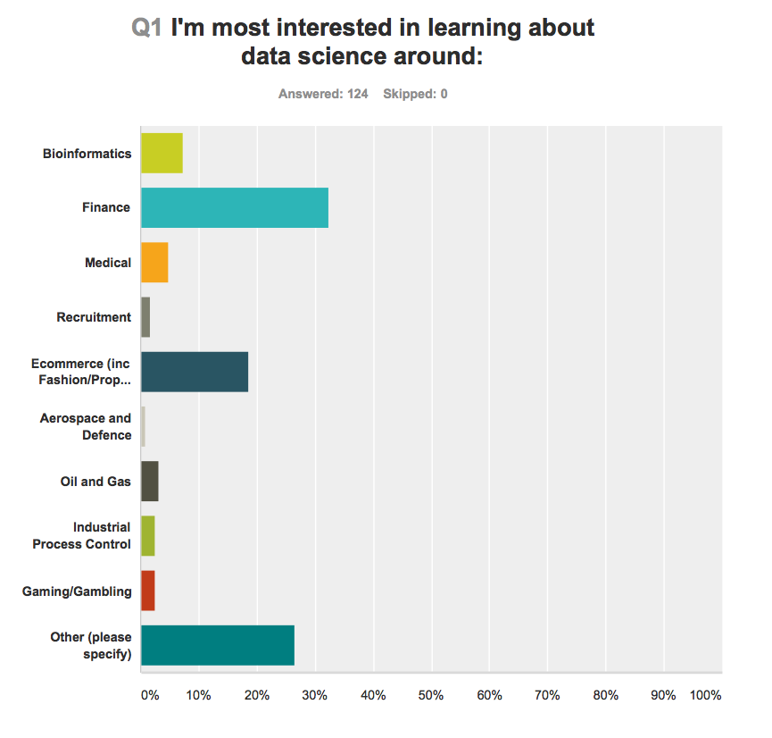

```python
Image(filename="images/pydata-survey_interested-topics.png", width=600)
```

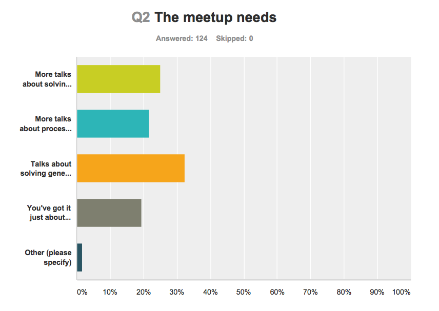

```python
Image(filename="images/pydata-survey_meetup-needs.png", width=600)
```

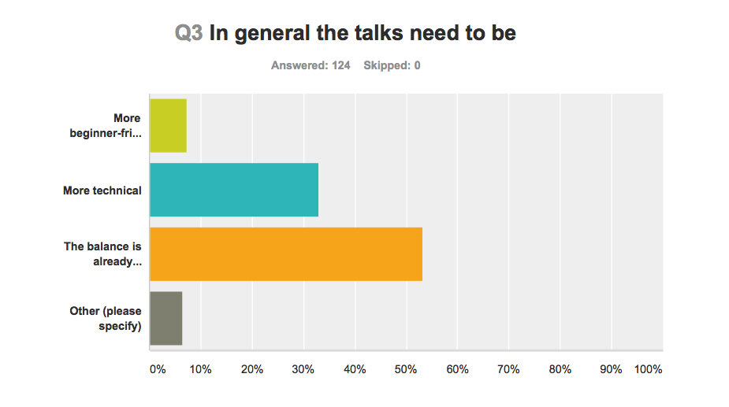

```python
Image(filename="images/pydata-survey_talks-need-to-be.png", width=600)
```

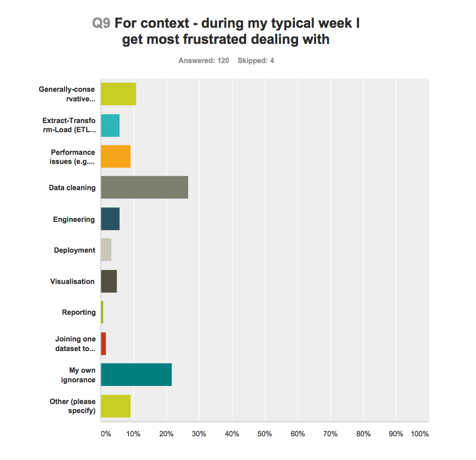

```python
Image(filename="images/pydata-survey_common-frustrations.png", width=600)
```

# POTM, DDT - multiply one test case by running it with different test data

- A collection of decorators to throw more data at tests
- Can read data from file! `@file_data`

```
@file_data('testdata.json')
def test_larger_than_two(self, value):
    self.assertTrue(larger_than_two(value))
```

```
# use your favourite tester!
nosetests -v test/test_example.py
```

# PyData Conference 2015 Videos! Well ... 90.4% are

- PyDataTV Youtube Channel
- Playlist "PyData London 2015" https://www.youtube.com/playlist?list=PLGVZCDnMOq0q6hrjJA56bq18eHtGusYJK

[figure not shown]

```python
Image('images/pydata_conf_playlist.png')
```

```python
YouTubeVideo('Yqy1F4fs1k0',600,400)
```

[video not shown]

```python
YouTubeVideo('T138eQjEASs', 600, 400)
```

[video not shown]

```python
YouTubeVideo('-LDXqGFD-Qw', 600, 400)
```

[video not shown]